# Crib Note - France ’40

This crib note does not include all the rules. The missing parts should be inferred using the general rules I assume.

## Terrain

- Marsh River is a Major River.
- Marsh around a minor River upgrades the hexside to a Major River hexside.

## Unit Type

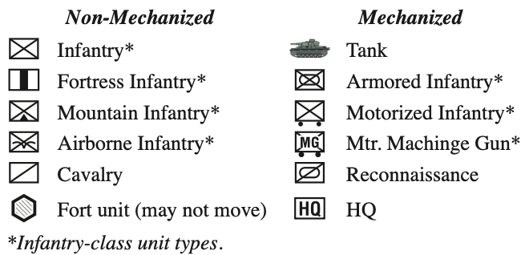

## 4. Stacking

- Can stack up to 7 Stacking Points (SPs).
- Units of the same division is 3- SPs.
- Every stack is allowed to have one tank unit with 2- SP even if exceeding the stacking limit.

## 5. ZOC

- HQs and static Fort units do not exert ZOC (white border lines).
- Do not extend to All-sea/Tital River hexsides.
- There are three cases for ZOC: uncontested, contested, and negated.
- **Entering EZOC**: Stop upon entering. No extra cost.
- **Leaving EZOC**: +2MPs. May move directly from EZOC to another EZOC unless crossing ZOC Bond.
- **Losing ZOCs**: [In entry hex / under Train / Full Retreat]

## 6. ZOC Bond

- **Eligibility**: Good Order 2+ DEF STR. Can form a ZOC Hexside Bond with a friendly map edge.
- **Restriction**: Cannot extend [through a City Hex / across an All-Sea Tidal River hexside / across two Major river hexsides]. When determining if [City Hex / Major River] breaks, push the Hexside Bond one side; may not be pushed into a enemy unit.

## 7. Movement

- **Extended Movement** increase MA. May not move adj to, but may begin adj from enemy unit.
- All Units and HQs can move 2- hexes by **Tactical Movement (TAC MOV)**.
- **Pontoon Bridges** exist at Major River hexside where both sides are occupied by friendly Combat Units; even [one unit is moving / during AAC / Disrupted / in Full Retreat]. A unit forming it may move after providing other units crossings.
- **Crossing Unbrided Major Rivers**: Must start adj to unless Pontoon.
- Units may move normally after crossing rivers.

### 7.7 Automatic DS

- Occurs when adj units makes 10-1 (including Tank and TQ Shift).
- Units not participating can move through the vacated hexes.
- **Procedure**: AutoDS on attacking units → cannot move further that Movement Phase → during the next Combat Phase, cannot participate regular combat, but can AAC anytime → remove AutoDS.
- One stack in each Automatic DS attack may conduct BRK.

### 7.6 Allied Rail Movement

- **Entraining**: Good Order units can entrain at [Town / City] 4+ hexes from German units; may move 2- hexes to reach.
- **Rail Movement**: During movement phase, 15- rail hexes, 3- units per turn; must be [reinforcements / entrained in a previous turn]. Hexes traversed must be 4+ hexes from German [unit / controlled city]. May not end stacked with other Rail Moved Units.
- **Detraining**: Beginning Allied Movement Phase, replace Train by Disrupted. May detrain in any rail hex. Must detrain if force to retreat or find itself 4- hexes of an enemy unit at the start of its move.

## 8~10. Combat

- Need not pre-declare all. There exist 8-1 and 9-1 columns identical to 7-1.
- **Maximum STR**: 20 Defense after halving and doubling. 40 Attack before halving.
- **Allied Cooperation**: French, British and Belgian units may stack and defend together, but may not attack together.
- **Selecting Step losses**: Infrantry Remnants are the last steps to be lost. A full strength unit must be selected first if German Panzer or Motorized divisions stack together.

### Halving & Doubling

- **Halving**
  - Applied only once per combat.
  - Applies to individual unit and round up (Exception: 1-STR units are added up and then halved).
  - ATK STR when [OOS / across Major River or Maginot Line / out of a Restricted Hex].
  - DEF STR when Disrupted.
- **Doubling**
  - Applied only once per combat.
  - DEF STR if all attackers [across River / out of a Restricted Hex]

### Combat Shifts

- **Tank, Heavy Tank (always)**: DEF terrain permitting
  - ATK [across River / out of a Restricted Hex] cannot provide but negate defender’s unless Heavy Tanks.
- **Air Support**: max 1 per ATK
- **HQ**: max 1 per ATK
- **Elite Combined Arms**: Elite Mech and Inf stacked together
- **Low Quality Units**: all contributed units are Low

## 11. Determined Defense

- May attempt DD to cancel the Retreat portions.
- Any Good Order, not HQs nor entrained, can be Lead Unit; Fort Unit if possible.
- **French Collapse**: if Lead Unit is French and OOS at the moment of DD.
- **DD Air Support**: German only. Max 1 per DD. Air Unit spent on Defensive Support can provide DD Air Support at no extra cost.
- If DD removes the last step at a successful DD, the attacker may advance into the vacated hex but stop.

### 11.4. Desperate Defense

- Allowed when [retreating force elimination / port hex & losing it force OOS after retreat]. Must choose either DD or Desperate Defense before any roll.
- **Restriction**: [DS / DR4] cannot perform.
- **Procedure**: Attempt DD as usual manner. If Fail, apply “-/-1”, and try again until [retreat is cancelled / all defending units lost].
- The DD Air Support DRM is applied to every roll. Lead Unit may be selected for each attempt.

## 12. Retreats

- Retreating through friendly units do not disturb non-retreating units.
- Through EZOC does not always cause step loss
- Friendly not retreated in the current combat negate EZOCs in the hex they occupy.
- **Direction**: In the following priority, if possible, 1) No same hex twice, no zig-zag, 2) Not causing step loss, 3) X hexes away, lose steps for unfulfilled, 4) in Supply position.
- **Over-stacking**: May end retreat over-stacked, but should be resolved the next owning player’s Movement Phase end; if force to retreat again in the same phase, elimininated.
- **Eliminated** if one of the following:
  - off map, into prohibited hex, across ZBond
  - into two consecutive EZOC
  - into one uncontested EZOC other than the first retreat hex
  - ending in EZOC; may retreat exactly one more hex to avoid eliminiation (not allowed for after two consecutive EZOC)
  - across Major River even if bridge
- **Early Stopping without Penalty** if [retreated 1+ hexes & not ending in EZOC unless negated & into friendly City or Fortified (Allied only)]; Does not affect AAC result, Disruption, nor Full Retreat.

## 13. Distruption

- Disrupted when retreat 1-3.
- Exert ZOC, NO ZBond.
- TAC MOV only.
- May not attack.
- DEF STR halved (earn Tank Shift).
- HQ may not provide Shift nor Ready.
- Retain TQ, ZOC, and Tank Shift.
- Other units may enter or pass through friendly Disrupted units without becoming Disrupted.

## 13. Full Retreat

- when [DR4+ / disrupted & retreat again / voluntary during friendly Movement Phase; from disrupted or GQG] (Cannot voluntarily Full Retreat on GT1, Sickle Cut)
- NO ZOC, No ZBond.
- Full MA; Extended Movement possible, no +2MP for leaving EZOC, may not enter EZOC unless negated.
- May not ATK.
- Cannot contribute to Defense.
- HQ may not provide Shift nor Ready.
- Must retreat 2 hexes if adj by enemy units unless negated; the enemy may then continue moving/advancing/retreating.

## 13. Recovery

- dr if EZOC, automatic otherwise.
- Full Retreat may choose not to recover.

## 14. AAC

- Units stacked together but not participating the attack can AAC together.
- Except Limited Advance, may advance in any direction. No need to enter the vacated hex
- Stop upon entering EZOC (even if negated) unless the vacated.
- Stop upon crossing a Major River even if bridged; may only cross during the first hex of AAC.
- Cannot enter Restricted nor prohibited.

## 15. Breakthrough Combat

- **Procedure**: 1) Declare one BRK Group , 2) conduct AAC and BRK combat, 3) conduct AAC of the other units in attack
- **Breakthrough Group**: With AAC eligible units. Apply Stacking Limit & Allied Cooperation. Can form in the vacated hex.
- May DD Air Support if Air Unit already in the hex.
- If **fails** to vacate or force to retreat, end the AAC.
- If **succeess**, continue the AAC from the [vacated (at no extra cost) / launched] hex; if ends in the vacated while EZOC, end or try another to free itself.
- Can drop off units from the BRK Group. The dropped end the AAC.
- Unlike retreats from regular Combat, units that have already retreated may defend against BRK combat and are not eliminated if forced to retreat again; if overstacked, the defender choose some not to contribute.

## 16. Fortfications

- **Fort Unit**: eliminated if forced to retreat
- German never benefit from Allied Fortified Hexes.

## 17. Allied HQs

- To provide HQ Shift, the HQ must 7- hexes to participating friendly unit and have the same nationality of one of the participating units.
- May TAC MOV maintaining Ready or consider it as Mech by Used.
- Adj alone to enemy unit, retreat 2 hexes & Disrupted; Full Retreat if already Disrupted.
- Ready if Allied Initial Phase & Good Order & In Supply to W, S, SE, or E Entry Hex.
- No dr if IS; instead eliminate if OOS & no LOC to Allied non-HQ units at Allied Supply Phase end.

## 18. Supply

- Check during owning player’s Supply Phase; In Supply if trace LOC. OOS otherwise.
- **Supply Source**: See Scenario rules. Allied tracing three friendly controlled City is In Supply.
- **Line of Supply**: Consist of 5- hexes overland portion, and then, may use unlimited length of road portions; overland Wood Rough and Marsh costs 2 hexes.
  - **Overland Portion**: prohibited entering [enemy controlled City / one uncontested EZOC / two consecutive EZOC; presence negates]
  - **Road Portion**: prohibited entering [enemy controlled City / EZOC; presence negates].
- **OOS Effects**: Only TAC MOV. ATT STR havled. AAC 2- hexes. No replacements.
  - Note. OOS allows ZOC, TQ, Tank Shift, full DEF STR.

### 18.5. Isolation Attrition

- dr individually if red OOS except [HQ / not adj to enemy / overland LOC to any length / Fort Units if stacked or adj to friendly non-Fort unit]
- Fort itself provides +2 DRM.
- May lose the last step.

## 19. Reinforcements

- **Entry Hex** is not playable. Reinforcements may not remain in those hexes or attack from them. Closed if Good Order enemy exit the Entry hex.
- During Movement Phase through Entry paying TEC cost of the first hex entered; May reinforce on ZOC but stop; delayed to the following turn if entry impossible.
- May use full MA on arrival.
- **Allied** (Sickle Cut): Random draw as per TRT. See Reinforcement areas on the counters. Place one per hex if possible; two if impossible. May delay to enter via adj Entry area by Strategic Rail MOV; Put Rail MOV marker.
- **German**: Max one division on each Entry Hex per turn; May 2 or 3 units constitute a division, not applicable to indep battalion (may enter with a division). Area A (north) is available once some enters on the area.

## 20. Special Rules

- **Recon Unit**: Yellow DEF STR. Ignores step loss of [D1 / DS] if attacked alone in a hex.
- **Rommel**: For each time ATK, DEF, BRK, and lead DD, allowed one re-roll each.
- **Montgomery**: If DEF & Good Order, allowed one re-roll for each CRT and DD; Rommel decide rerolling first if both present.
- **Disengagement**: Good Order attacker may attempt Disengagement attack once during any point of friendly Combat Phase. dr for each unit or group of units (owner’s choice). Retreat 2- hexes in any direction if successful. DIS but recover.

## 21. Sickle Cut Scenario

- **Supply Source**: A, B, C, and D Entry for Axis; other Entry for Allied
- **The Dyle Line**: Under constructions are finished at GT1 Allied Movement Phase end if 1+ Inf start there and stay there. Act as Fortified Hex. Remove if [boxed H on DD / unit in the hex are eliminated or force to retreat / no friendly units owning player’s Supply Phase end].
- **German Mass Air Strike**: Max 3 Air in a single combat on GT1
- **Additional Turn (Optional)**: Upon agreement at game start, on GT10, player with 5+VP pay 3VP to extend the game one additional turn.

### 21.2. GQG (Grand Quartier General)

- **Effects**: To slow down and prevent ATK.
  - Must stacked together; not split.
  - May only TAC MOV.
  - May not ATK or Disengagement.
  - May not stop voluntarily in a hex containing GQG; allowed for a while upon inevitable situation of Retreats, resolve ASAP.
  - At any Phase end, suffer GQG if stacked with; but can pass without affected.
- **Abilities**: May enter EZOC. Retain ZOC, TQ, Tank Shift, Full DEF, and Lead DD.
- **Units Exempt**: HQ and 4th DCR (de Gaulle). Free from, may freely exit and pass through GQG.

### 21.2.4. The GQG Phase

- On GT1, place six GQG
- GT2+, place from GQG Holding Box.
- One per hex, on any Allied stack with 1+ French (even if under Train)
- two dr to return 2-
- **Return to Holding Box**: If GQG stack [eliminated / Disrupted / Full Retreat]; Allied may not voluntarily Full Retreat GQG units.
- **Scheduled Removal**: GT3+, before placement during GQG Phase, remove one in the numerical order per turn from play (1→2→…).

### 21.3. von Rundstedt’s Halt Order

- **When**: Once per game, any turn GT5+, during Allied Supply Phase.
- **How**: Place 6- Halt markers on hexes containing 1+ German Mech; selected must be West further than all German non-Mech divisions. 3- hexes from German non-Mech cannot be selected.
- After placement, two dr to remove the markers matching the each dr.
- **Effect**: Same as GQG. Last for one German turn; remove after.

### 21.7. Victory Condition

**Allied**

- 10VP if [X / N] and [S / W] have railroad connection; must be free from German unit or EZOC.
- 5VP if not above, but can trace LOS from [X / N] to [S / W]; 5- overland & road to [S / W].
- 1VP per eli multi-step German unit (3-step’s REM should be eliminated to count); Single-step battalion worth no VP.
- 1VP per multi-step German Mech with no LOC of anylength

**German**

- 10VP if Allied rail connection fails.
- 1VP for each Allied Entry closed; 2VP for S/SE near Reim; to count, must LOS at the game end.
- 1VP per German exited [X]; must trace LOS at the instant of exit.